# Part 3: Modelling with R

Author

Verónica Andreo

Published

April 6, 2023

In this third part of the studio, we’ll use R to model *Aedes albopictus* distribution in Northern Italy. For that, we need to connect to GRASS via the `rgrass` package in order to read occurrence data and predictors. The *rgrass* package is developed by Bivand (2022) and can be found at: https://github.com/rsbivand/rgrass/. See the vignette with further explanations and examples at: https://rsbivand.github.io/rgrass/.

# [**rgrass**](https://cran.r-project.org/web/packages/rgrass/index.html)

- `initGRASS()`: starts a GRASS GIS session from R
- `execGRASS()`: executes GRASS GIS commands
- `gmeta()`: shows GRASS location metadata
- `read_VECT()` and `read_RAST()`: read vector and raster maps from GRASS into R *terra* objects.
- `write_VECT()` and `write_RAST()`: write R *terra* objects into the GRASS GIS database

**Note**

Package `terra` is developed by Hijmans (2022) and will eventually replace `raster`.

## Usage

GRASS GIS and R can be used together in two ways:

A. Using [R within a GRASS GIS session](https://grasswiki.osgeo.org/wiki/R_statistics/rgrass7#R_within_GRASS), i.e. starting R (or RStudio) from GRASS terminal

- type `R` or `rstudio &` in the GRASS GIS terminal
- load `rgrass` library
- use `read_VECT()`, `read_RAST()` to read data from GRASS into R
- access GRASS GIS modules and database through `execGRASS()`
- write data (back) to GRASS database with `write_VECT()` and `write_RAST()`

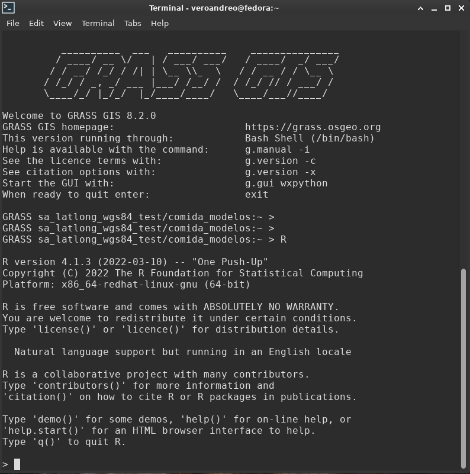

B. Using [GRASS GIS within an R session](https://grasswiki.osgeo.org/wiki/R_statistics/rgrass7#GRASS_within_R), i.e. we connect to GRASS GIS database from within R (or RStudio).

- we need to start GRASS GIS with `initGRASS()` from R
- we access GRASS GIS modules through `execGRASS()`
- use `read_VECT()`, `read_RAST()`, `write_VECT()` and `write_RAST()` to read data from and to GRASS database

**Note**

`rgrass` was originally intended to apply GRASS functions on data outside GRASS database; hence some prefer to create throw away locations

[figure not shown]

# SDM workflow

In this part of the Studio we’ll be covering the middle and right side of the SDM workflow, modeling and predictions.

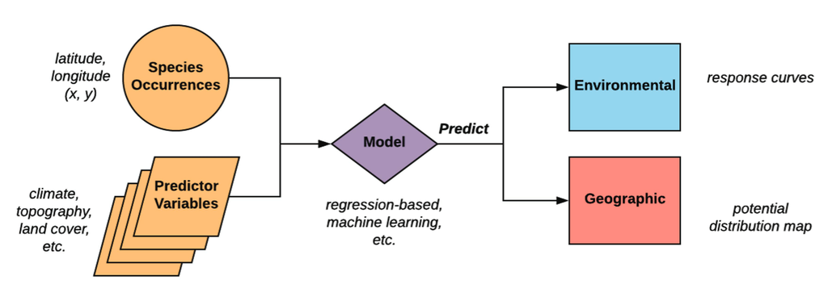

There are several packages to carry out SDM, in this case we’ll be using [SDMtune](https://cloud.r-project.org/web/packages/SDMtune/index.html) by Vignali et al. (2020). It provides functions covering the whole SDM workflow, from data preparation, to variable selection, optimization and evaluation. Have a look at the articles on the package website for further details: https://consbiol-unibern.github.io/SDMtune/index.html.

# Let’s move to R

### Load packages needed

```r
library(rgrass)
library(sf)
library(terra)
library(mapview)
library(biomod2)
library(dismo)
library(usdm)
library(SDMtune)
library(zeallot)
```

### Initialize GRASS

We’ll use **option B**, i.e., we’ll launch GRASS GIS in a defined location and mapset, from R

```r
# path to GRASS binaries (run `grass --config path`)
grassbin <- "/usr/lib64/grass82"
# path to GRASS database
grassdata <- "/home/veroandreo/grass_ncsu_2023/grassdata/"
# path to location
location <- "eu_laea"
# path to mapset
mapset <- "italy_LST_daily"

# start GRASS GIS from R
initGRASS(gisBase = grassbin,
          home = tempdir(),
          gisDbase = grassdata,
          location = location,
          mapset = mapset,
          override = TRUE,
          remove_GISRC= TRUE)
```

### Read vector data

Now we read in the occurrence data and the background points hosted in GRASS, convert them to `sf` objects and display them with `mapview`.

```r
# Read vector layers
presence <- st_as_sf(read_VECT("aedes_albopictus"))
background <- st_as_sf(read_VECT("background_points"))
```

#### Read raster data

We read now all the variables that we derived from the daily LST time series.

```r
# List rasters by pattern
worldclim <- execGRASS("g.list",
                       parameters = list(type = "raster",
                                         pattern = "worldclim*"))
avg <- execGRASS("g.list",
                 parameters = list(type = "raster",
                                   pattern = "avg*"))
median <- execGRASS("g.list",
                    parameters = list(type = "raster",
                                      pattern = "median*",
                                      exclude = "*[1-5]"))

# Concatenate map lists
to_import <- c(attributes(worldclim)$resOut,
               attributes(avg)$resOut,
               attributes(median)$resOut)

# Read raster layers
predictors <- list()
for (i in to_import){
  predictors[i] <- read_RAST(i) }

# Stack rasters
predictors_r <- rast(predictors)
```

Let’s visualize imported maps. Note we convert *terra* object into *raster* because `mapview` does not support terra yet.

```r
# Quick visualization in mapview
mapview(raster::raster(predictors_r[['worldclim_bio01']])) + presence
```

#### Data preparation

Now that we have imported presence records, background points and predictor variables derived from LST time series, we need to prepare the data in a format called *samples with data* (SWD). This is basically a table with presence and background coordinates plus the corresponding values in the predictor variables.

```r
# Variables for models
sp <- "Aedes albopictus"
presence_coords <- st_coordinates(presence)
background <- st_coordinates(background)
env <- predictors_r

# Prepare data: SWD
data_sp <- prepareSWD(species = sp,
                      p = presence_coords,
                      a = background,
                      env = env)

data_sp
```

### Define relevant variables

We define here some of the input values required through the workflow:

```r
seed=49
perc_test = 0.2
k = 4
method="Maxent"
cor_th=0.7
perm=10
imp_th=10
```

### Create train and test datasets

We will train the model with an 80% of presence samples, and leave the remaining 20% for evaluation at the end.

```r
# Create training and test sets
c(train_sp, test_sp) %<-%
  trainValTest(data_sp,
               test = perc_test,
               only_presence = TRUE,
               seed = seed)
```

```r
train_sp
```

```r
test_sp
```

### Create folds for cross-validation

As we will use cross-validation during the model training, we create the folds in advance. In this case we use random folds, but other methods exist. Since we are limited by the number of presence records, we will create only 4 folds. The algorithm will iteratively use 3 folds to train and 1 to validate.

```r
# Create folds
ran_folds <- randomFolds(train_sp,
                         k = k,
                         only_presence = TRUE,
                         seed = seed)
```

### Train a default Maxent model with CV

We will first train a so called *full model*, i.e., a model with all predictors, and from there we’ll remove those that are highly correlated and not so important.

```r
# Train a full model
full_model_sp <- train(method = method,
                       data = train_sp,
                       folds = ran_folds)

full_model_sp
```

Let’s see the predictions of the full model

```r
pred_full_model <- predict(full_model_sp,
                           data = env,
                           type = "cloglog")

mapview(raster::raster(pred_full_model))
```

### Variable selection: remove highly correlated variables

We proceed then to remove correlated predictors as they provide highly redundant information and might affect the performance of models, i.e., as with all models, we want it to be simple and of the highest possible performance. We will use the area under the ROC curve (AUC) as the performance metric, and eliminate correlated variables only if AUC decreases if we keep them.

```r
# Prepare background locations to test correlation
bg_sp <- prepareSWD(species = sp,
                    a = background,
                    env = env)

# Remove variables with correlation higher than 0.7
# while accounting for the AUC
vs_sp <- varSel(full_model_sp,
                metric = "auc",
                bg4cor = bg_sp,
                cor_th = cor_th,
                permut = perm,
                interactive = FALSE)
```

Let’s explore the output object

```r
vs_sp@data
```

### Remove less important variables

After discarding correlated variables, we will also remove variables that have a percent contribution or importance lower than 10%, again accounting for AUC.

```r
# remove less important variables only if auc does not decrease
reduc_var_sp <- reduceVar(vs_sp,
                          th = imp_th,
                          metric = "auc",
                          test = TRUE,
                          permut = perm,
                          use_jk = TRUE,
                          interactive = FALSE)
```

Let’s explore the result

```r
reduc_var_sp
```

We need now to recreate the SWD object and train/test datasets, but with the selected variables only, in order to run the final model and make predictions.

```r
# Get only relevant variables from the reduced model
retained_varnames <- names(reduc_var_sp@models[[1]]@data@data)

# Subset stack
env <- terra::subset(env, retained_varnames)

# SWD with the selected vars
subset_train_sp <- prepareSWD(species = sp,
                              p = presence_coords,
                              a = background,
                              env = env)

c(train_sp, test_sp) %<-%
  trainValTest(subset_train_sp,
               test = perc_test,
               only_presence = TRUE,
               seed = seed)
```

### Run the best model and make predictions

Now we train the final model with the full training set, we no longer need the folds at this point. Note that we also use the feature classes (fc) and regularization (reg) from the best model obtained before. In this case, they are default values only, but if we also do hyper-parameter optimization, they might differ.

```r
final_model_sp <- train(method = method,
                        data = train_sp,
                        fc = reduc_var_sp@models[[1]]@model@fc,
                        reg = reduc_var_sp@models[[1]]@model@reg)
```

Let’s make predictions now and explore the result

```r
map_sp_maxent <- predict(final_model_sp,
                         data = env,
                         type = "cloglog")

mapview(raster::raster(map_sp_maxent))
```

### Write result back to GRASS

We can now write the raster with the final model’s predictions into the GRASS database.

```r
write_RAST(map_sp_maxent,
           "Aedes_albopictus_maxent",
           flags = c("o","overwrite"))
```

Check the map is there

```r
execGRASS("g.list",
          parameters = list(type="raster",
                            pattern="Aedes*"))
```

### Model evaluation

We want to know how good our model is, so in this step we use the test dataset that we separated in the beginning. An AUC of 0.5 would mean the model performs like flipping a coin. AUC is what we call a threshold independent evaluation metric.

```r
# AUC
auc_maxent <- auc(final_model_sp, test = test_sp)
auc_maxent
```

Usually, however, the result of SDM is converted into presence/absence maps. To determine which threshold to use we perform threshold dependent evaluations.

```r
# Threshold dependent evaluation
th_maxent <- thresholds(final_model_sp,
                        type = "cloglog",
                        test = test_sp)

knitr::kable(th_maxent, format = 'html', digits = 2)
```

Let’s choose one threshold and create a binary map

```r
p = map_sp_maxent >= 0.5
a = map_sp_maxent < 0.5
map_sp_maxent[p] <- 1
map_sp_maxent[a] <- 0

mapview(raster::raster(map_sp_maxent))
```

### Variable importance

Variable importance is an indicator of variable contribution to prediction.

```r
vi_model_sp <- maxentVarImp(final_model_sp)
vi_model_sp
```

```r
plotVarImp(vi_model_sp)
```

### Response curves

Response curves give us an idea of the relationship between predictor variables and probability of occurrence.

```r
my_rp <- function(i){
  plotResponse(reduc_var_sp, i)
}

plotlist <- lapply(retained_varnames, my_rp)

labels <- LETTERS[1:length(retained_varnames)]

ggpubr::ggarrange(plotlist = plotlist, labels = labels)
```

We close the mapset and done

```r
# close the mapset
unlink_.gislock()
```

### Disclaimer

This is only a simple example for doing SDM and only the beginning… There are:

- other models to test
- hyper-parameter tuning
- ensemble modeling
- uncertainty assessment: where we can predict with confidence
- many other relevant packages:
  - [*dismo*](https://cran.r-project.org/web/packages/dismo/index.html), [*sdm*](https://cran.r-project.org/web/packages/sdm/index.html), [*kuenm*](https://github.com/marlonecobos/kuenm), [*caret*](https://cran.r-project.org/web/packages/caret/index.html), [*CAST*](https://cran.r-project.org/web/packages/CAST/index.html), etc.

## References

Bivand, R. (2022), *[Rgrass: Interface between ’GRASS’ geographical information system and ’r’](https://CRAN.R-project.org/package=rgrass)*.

Hijmans, R. J. (2022), *[Terra: Spatial data analysis](https://CRAN.R-project.org/package=terra)*.

Vignali, S., Barras, A. G., Arlettaz, R., and Braunisch, V. (2020), “SDMtune: An r package to tune and evaluate species distribution models,” *Ecology and Evolution*, 00, 1–18. https://doi.org/10.1002/ece3.6786.